# beatochess no. 06 (December 2024)

### Tarrasch +0100.02e7f5 (1925). Correction

Date: 2024, November 26

File: Tarrasch1925.pgn

Tarrasch’s didactic endgame is even won with the bP on g5.

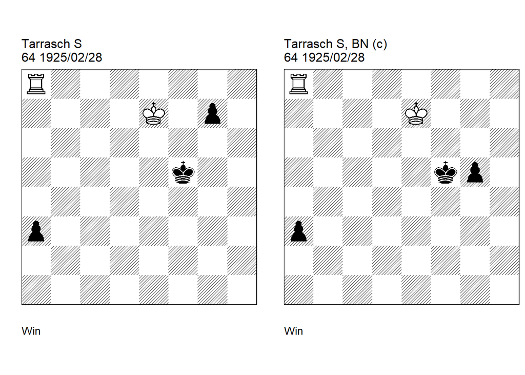

GBR: +0100.02e7f5 FEN: R7/4K1p1/8/5k2/8/p7/8/8 w - - 0 1

**64=4 after game Tarrasch=S - Schlechter=C Koln 1911. U1: Kopaev=N Shakhmaty v SSSR/3 1953 U2: Haworth=G Bleicher=E HHdbV 74513 9-12-2009. 1. Kd6** (1. Rxa3? g5 2. Ra5+ Kf4 3. Kf6 g4 4. Ra4+ Kf3 5. Kf5 g3 6. Ra3+ Kf2 7. Kf4 g2 8. Ra2+ Kf1 9. Kf3 g1=N+) (1. Ra5+! cook NK 1… Kf4 2. Ke6 g5 3. Ra4+ Kf3 4. Kf5) **1… g5** (1… Ke4 2. Ke6 g5 3. Ra4+ Kf3 4. Kf5) **2. Kd5 Kf4!** (2… g4 3. Rf8+) **3. Kd4 g4** (3… a2 4. Rxa2 g4 5. Rf2+) **4. Rf8+! Kg3 5. Ke3 Kh2** (5… a2 6. Ra8 Kh3 7. Rxa2 g3 8. Kf3) **6. Rh8+** (6. Ra8! cook GH/EB ) (6. Rf2+! cook GH/EB ) **6… Kg2 7. Ra8 g3 8. Rxa3** (8. Ke2! cook GH/EB ) **8… Kh1 9. Ra1+ Kh2** (9… Kg2 10. Ke2) **10. Kf3 g2 11. Kf2!** (11. Ra2? Kh1 12. Rxg2) **1-0**.

GBR: +0100.02e7f5 FEN: R7/4K3/8/5kp1/8/p7/8/8 w - - 0 1

**correction: Neuenschwander=B beatochess 26/11/2024. 1. Kd6 g4** (1… Ke4 2. Ra4+) **2. Kd5 Kf4 3. Kd4 g3 4. Rf8+ Kg4 5. Ke3** (5. Ke4 or ) (5. Rf1? g2 6. Ra1 Kf3) **1-0**.

### Voinov +0351.25h2g8 (1925). Correction

Date: 2024, November 26

File: Voinov1925.pgn

Voinov’s study is a mistery: in addition to the cook on move 2, **1. Nb4!** leads to a mate in four moves, and some of the pawns are simply not needed. The correction is more parsimonious and adds the try 1. Nf4.

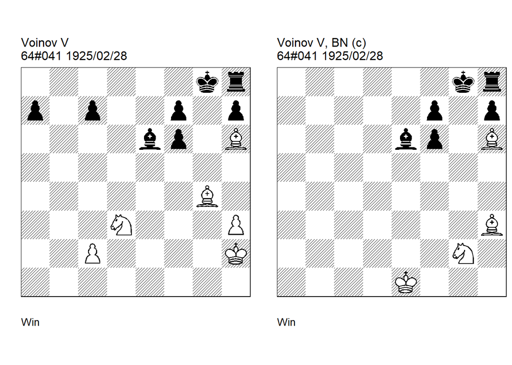

GBR: +0351.25h2g8 FEN: 6kr/p1p2p1p/4bp1B/8/6B1/3N3P/2P4K/8 w - - 0 1

**64=4 . U2: 64=20 30-10-1925. U1: Neuenschwander=B beatochess 26/11/2024. 1. Bf5** (1. Nb4! cook BN 1… f5 2. Nc6 f6 3. Bh5 f4 4. Ne7 ) **1… Bxf5 2. Nf4** (2. Nf2! cook 2… a5 3. Kg3 a4 4. Kf4 a3 5. Kxf5 a2 6. Ng4 a1=Q 7. Nxf6+ Qxf6+ 8. Kxf6) **2… Be6** (2… Bg6 3. Nd5 f5 4. Nf6 ) **3. Nh5 f5 4. Nf6 1-0**.

GBR: +0351.03e1g8 FEN: 6kr/5p1p/4bp1B/8/8/7B/6N1/4K3 w - - 0 1

**correction: Neuenschwander=B beatochess 26/11/2024. 1. Bf5!** (1. Nf4? f5 2. Bf1 Ba2! (2… Bb3? 3. Kd2 f6 4. Kc3 Ba2 5. Kb2) 3. Kd2 f6) **1… Bxf5 2. Nf4 Be6** (2… Bg6 main 3. Nd5) **3. Nh5 1-0**.

### Zalkind +0071.32g2a5 (1925). Cook, correction

Date: 2024, November 26

File: Zalkind1925.pgn

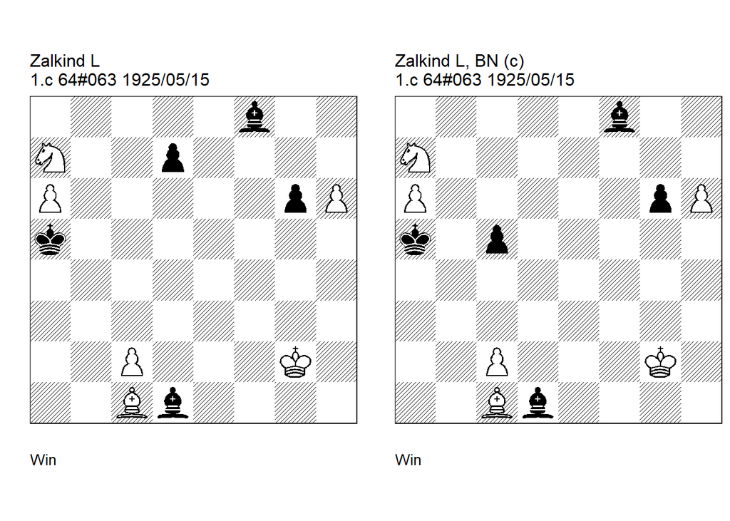

GBR: +0071.32g2a5 FEN: 5b2/N2p4/P5pP/k7/8/8/2P3K1/2Bb4 w - - 0 1

**64=9 . U1 U2: Garcia=M HHdbV 74388 23-9-2011. 1. h7** (1. Nc6+! cook MG 1… Kxa6 2. h7 Bg7 3. Nb4+ Kb5 4. Nd3 d5 5. Bf4 Bxc2 6. Be5 Bxd3 7. Bxg7) **1… Bg7 2. Bb2** (2. Nc6+! cook MG 2… Kb6 3. Nb4) **2… Bxb2 3. c3! Bxc3 4. Nb5 Kxb5 5. a7 1-0**.

GBR: +0071.32g2a5 FEN: 5b2/N7/P5pP/k1p5/8/8/2P3K1/2Bb4 w - - 0 1

**correction: Neuenschwander=B beatochess 26/11/2024. 1. h7 Bg7 2. Bb2 Bxb2 3. c3 Bxc3 4. Nb5 Kxb5 5. a7 1-0**.

### Bondarenko & Kuznetsov +1030.44g1h4 (1974). Correction

Date: 2024, December 2

File: Bondarenko1974a.pgn

White can also transform into a winning pawn ending with **1. Qh2** or **3. Qxf2+**.

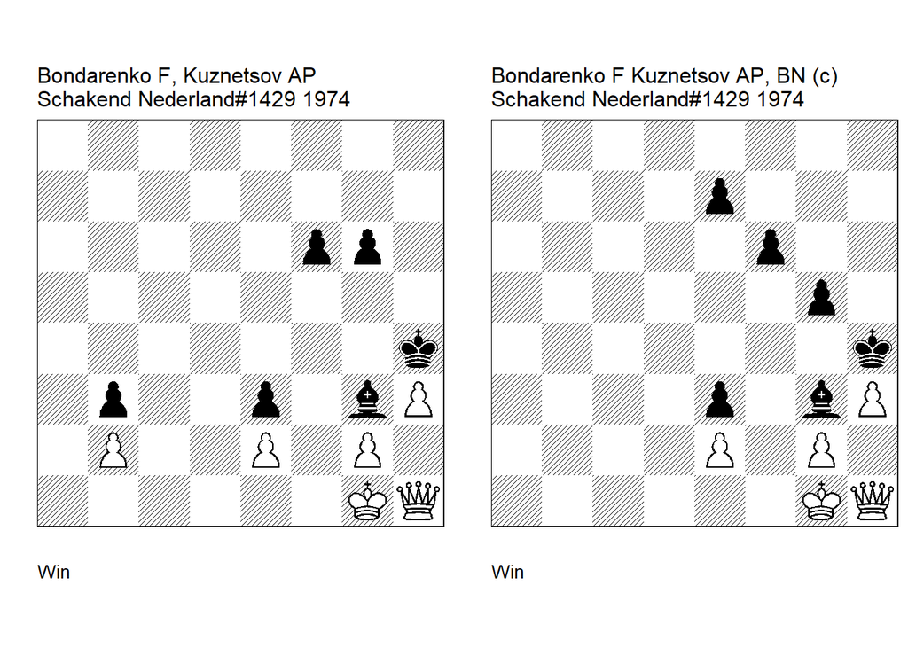

GBR: +1030.44g1h4 FEN: 8/8/5pp1/8/7k/1p2p1bP/1P2P1P1/6KQ w - - 0 1

**Schakend Nederland/1 1975 . U2: Mees=W Spinhoven=F Schakend Nederland/10 1975 U2: Ulrichsen=J HHdbIV 41971 22-9-2006. U1: Neuenschwander=B beatochess 02/12/2024. 1. Kf1** (1. Qh2! cook BN ) **1… f5 2. Qg1 Bf2 3. Qh2** (3. g3+! cook JU ) (3. Qxf2+! cook BN ) **3… Bg3 4. Qh1 f4** (4… Kh5 5. h4 ) **5. Qg1 Bf2 6. Qh2 Bg3 7. Qh1 g5 8. Qg1 Bf2 9. Qh2** (9. Qxf2+! cook WM/FS 9… exf2 10. Kxf2) **9… Bg3 10. Qh1 Kh5 11. h4 g4 12. Qg1 Bf2 13. Qh2 Bg3** ( 13… Bxh4 14. g3) **14. Qh1 Kg6** (14… Bxh4 15. g3) **15. h5+ Kh6 16. Qg1 Bf2 17. Qh2 Bg3 18. Qh1 Kg7 19. h6+ Kh7 20. Qh5 1-0**.

GBR: +1030.34g1h4 FEN: 8/4p3/5p2/6p1/7k/4p1bP/4P1P1/6KQ w - - 0 1

**correction: Neuenschwander=B beatochess 02/12/2024. 1. Kf1 f5 2. Qg1 f4 3. Qh1 Kh5 4. h4 g4 5. Qg1 Bf2 6. Qh2 Bg3 7. Qh1 e6 8. Qg1 Bf2 9. Qh2 Bg3 10. Qh1 e5 11. Qg1 Bf2 12. Qh2 Bg3 13. Qh1 e4 14. Qg1 Bf2 15. Qh2 Bg3 16. Qh1 Kg6 17. h5+ Kh6 18. Qg1 Bf2 19. Qh2 Bg3 20. Qh1 Kg7 21. h6+ Kh7 22. Qh5 1-0**.

### Bondarenko & Kuznetsov =0312.55f3a1 (1974). Version

Date: 2024, December 3

File: Bondarenko1974b.pgn

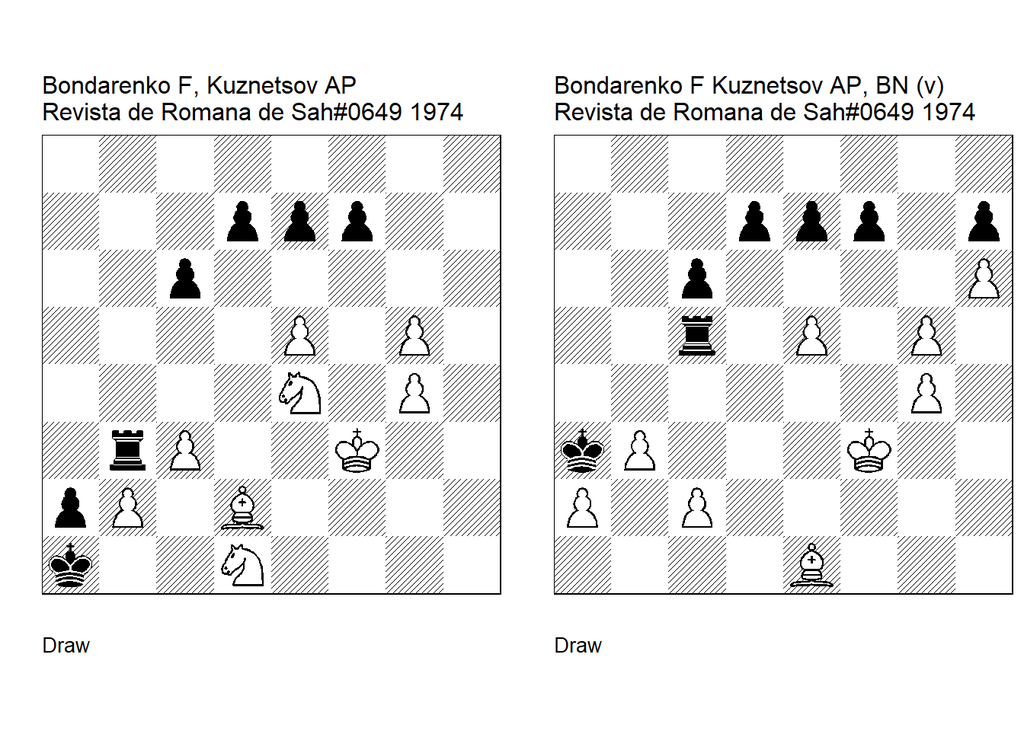

GBR: =0312.55f3a1 FEN: 8/3ppp2/2p5/4P1P1/4N1P1/1rP2K2/pP1B4/k2N4 w - - 0 1

**Revista de Romana de Sah/3. U2: Garcia=M HHdbV 41274 22-9-2011. 1. Nc5 Rb5 2. c4!** (2. Nxd7! cook MG 2… Rd5 (2… Kb1 3. e6 fxe6 4. g6 a1=Q 5. g7) 3. e6 fxe6 4. g6 Rxd7 5. c4 Kb1 6. Nc3+ Kxb2 7. Nxa2 Kxa2 8. Ke4) **2… Rxc5 3. b3! Kb1 4. Nc3+ Kb2 5. Nxa2 Kxa2 6. e6!** (6. g6? fxg6 7. e6 d6) **6… dxe6 7. g6! fxg6 8. Bb4 Re5 9. Bc3 Rg5 10. Bd2** (10. Kf4? Kxb3 11. Kxg5 Kxc3 12. Kxg6 e5 13. Kf5 Kd4 14. g5 e4 15. g6 e3 16. g7 e2 17. g8=Q e1=Q) **10… Re5 11. Bc3 1/2-1/2**.

GBR: =0310.75f3a3 FEN: 8/3ppp1p/2p4P/2r1P1P1/6P1/kP3K2/P1P5/4B3 w - - 0 1

**version: Neuenschwander=B beatochess 03/12/2024. 1. e6! dxe6 2. g6! fxg6 3. c4! Kxa2 4. Bb4 Rg5 5. Bd2 Re5 6. Bc3 Rc5 7. Bb4 Re5 8. Bc3 Rg5 9. Bd2 1/2-1/2**.

### Kuznetsov AP =0415.12f5b1 (1972). Comment

Date: 2024, December 3

File: Kuznetsov1972.pgn

The study seems to be correct.

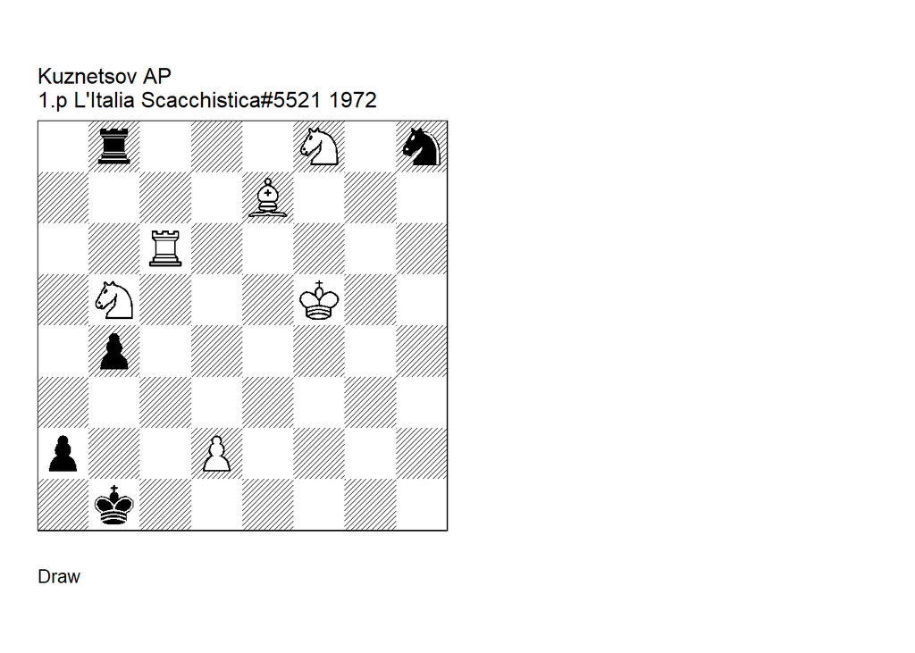

GBR: =0415.12f5b1 FEN: 1r3N1n/4B3/2R5/1N3K2/1p6/8/p2P4/1k6 w - - 0 1

**L’Italia Scacchistica=806 L’Italia Scacchistica/12** (EG 02220) **. U1: Nunn=J HHdbIII 29269 31-8-2002. Comment Neuenschwander=B beatochess 03/12/2024. 1. Na3+!** (1. Bf6 Rxb5+ 2. Ke4 (2. Ke6! cook JN 2… Nf7! BN 3. Kxf7 Rf5 4. Ke7 Rxf6 5. Rxf6 b3 -/+) 2… Nf7! 3. Ra6 b3) **1… bxa3** (1… Kb2 2. Nc2) **2. Bxa3 Rxf8+** (2… a1=Q 3. Rc1+) **3. Ke6!** (3. Ke4? Re8+!) (3. Kg4? Rg8+!) **3… Rf6+!** (3… a1=Q 4. Rc1+ Ka2 5. Rxa1+ Kxa1 6. Bxf8) (3… Rf1 4. Rb6+ Kc2 5. Rb2+) **4. Kxf6! a1=Q+ 5. Rc3! Ka2** (5… Qa2 6. Rc1 ) ( 5… Nf7 6. Kxf7 Qa2+ 7. Kf6 Qd5 8. Bc1) **6. Bc1!** (6. Kg7? Qe1 7. Kxh8 Qxd2) **6… Kb1** (6… Qb1 7. Ra3 ) (6… Ng6 7. Kxg6 Qb1+ 8. Kg5 Qe4 9. Kf6) **7. Ba3!** (7. Kg7? Qa8 8. Ba3 Qd8 9. Bc1 Qd4+) **1/2-1/2**.

## Shakhmatny Listok (continued)

### Tyulin =0013.03c7f5 (1923). Cook

Date: 2024, December 27

File: Tyulin1923.pgn

**2. Bd7+** or **3. Bd7+** cook the study.

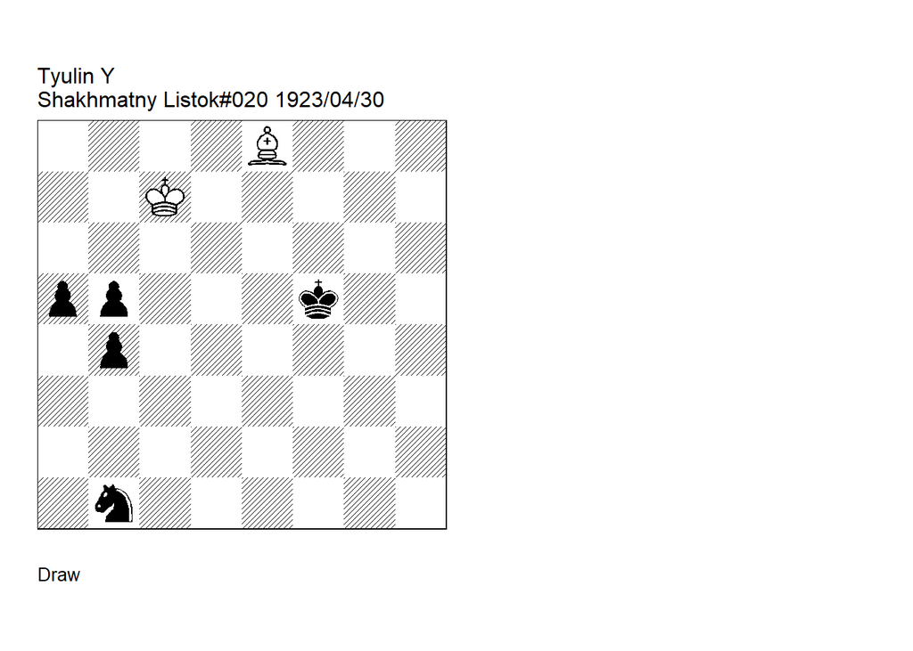

GBR: =0013.03c7f5 FEN: 4B3/2K5/8/pp3k2/1p6/8/8/1n6 w - - 0 1

**Shakhmatny Listok=15-16 . solution: Garcia=M HHdbVI 1-7-2015. U2: Neuenschwander=B beatochess 27/12/2024. 1. Kb6 Na3** (1… Nc3 main 2. Kxa5 b3 3. Kb4 b2 4. Ka3 b1=Q 5. Bg6+ Kxg6) (1… b3 2. Bxb5) **2. Kxa5** (2. Bd7+! ccok BN 2… Ke5 3. Kxa5 b3 4. Be8 Kf6 5. Bc6 Ke5 6. Be8) **2… b3 3. Kb4** ( 3. Bd7+! cook BN ) **3… b2 4. Kxa3 b1=Q 5. Bg6+ Kxg6 1/2-1/2**.

Date: 2024, December 31

File: Troitzky1923a.pgn

The cooks on move 1 and 6 can be avoided easily.

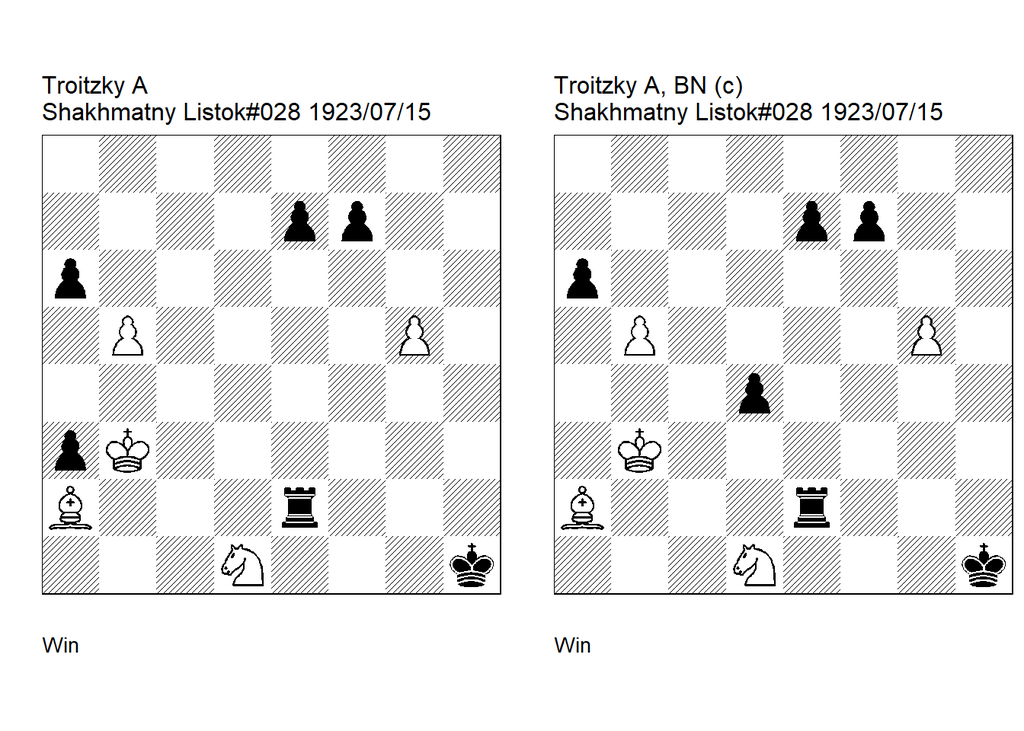

GBR: +0311.24b3h1 FEN: 8/4pp2/p7/1P4P1/8/pK6/B3r3/3N3k w - - 0 1

**Shakhmatny Listok=25-26. U1, U2: Neuenschwander=B beatochess 31/12/2024 . 1. b6!** (1. g6! cook BN 1… fxg6 2. b6 Re6 3. b7 Rb6+ 4. Kxa3 e6 5. Bxe6) **1… Re6!** (1… Rd2 2. Kc3) (1… Rh2 2. Kc3 e6 3. Bxe6 fxe6 4. g6) **2. b7 Rb6+ 3. Kxa3! e6 4. Bb1! Rxb1** (4… Kh2 main 5. Be4 Kg3 eg 6. Nb2 Kf4 7. Nc4 Rb5 8. Bc6 Rxb7 9. Bxb7 Kxg5 10. Bxa6 f5 11. Bb7 f4 (11… Kg4 12. Bc8) 12. Bf3) **5. Nb2 Ra1+ 6. Kb4** (6. Kb3! cook BN 6… Ra5 7. b8=Q Rb5+ 8. Qxb5 axb5 9. Nd3) **6… Ra2 7. Kc3 Ra3+ 8. Kc4 1-0**.

GBR: +0311.24b3h1 FEN: 8/4pp2/p7/1P4P1/3p4/1K6/B3r3/3N3k w - - 0 1

**correction: Neuenschwander=B beatochess 31/12/2024. 1. b6!** (1. bxa6? Re6 2. Kc2 Rxa6 3. Bxf7 Ra3 4. g6 Rg3 5. Nf2+ Kg2 6. Ne4 Rg4 7. Kd3 Kf3 8. Nc5 e5) (1. g6 fxg6 2. b6 Re6 3. b7 Rb6+ 4. Ka3 g5) **1… Re6! 2. b7 Rb6+ 3. Ka3 e6 4. Bb1! Rxb1 5. Nb2 Ra1+ 6. Kb4** (6. Kb3? Ra5 7. b8=Q Rb5+ 8. Qxb5 axb5 9. Nd3 Kg2 10. Ne5 d3 11. Kc3 (11. Nxd3 Kf3 12. Ne5+ Ke4 13. Nxf7 Kf5) 11… Kg3 12. Nxf7 Kf4 13. g6 Ke3) **6… Rb1 7. Kb3 1-0**.